# 무신사 모델과 스타일

# [분석 목적]

**1. 모델과 스타일간의 관계** **2. 스타일과 스타일간의 관계**

# [공통 내용]

**1. 남성과 여성 구분하여 분석** **2. 남성 스타일 종류에서 세부 스타일은 큰 스타일 범주 안으로 넣기로 결정하여 전처리함** ** (“스포츠 캐주얼 -> 스포츠”, “이지 캐주얼 -> 캐주얼”, “세미 포멀 -> 포멀”)**

## ————————————————————————

# 1. 모델과 스타일간의 관계

모델들이 어떤 스타일을 타겟으로 잡았는지, 많이 선택한 스타일은 무엇이 있는지 확인해보고자 네트워크를 그려보았습니다.

### 원데이터 확인

musinsa에서 크롤링한 데이터를 가져오고 데이터 구조를 확인합니다.

```r
setwd("D:/musinsa_store")

##데이터 가져오기
styling_woman <- read.csv("musinsa_styling_data_woman.csv")
styling_man <- read.csv("musinsa_styling_data_man.csv")

###styling_man
#데이터 구조 확인
head(styling_man, 5)
```

```
##        date
## 1 2017-9-28
## 2 2017-9-28
## 3 2017-9-28
## 4 2017-9-28
## 5 2017-9-28
##                                                                                                                                                                                           styling_url
## 1 https://store.musinsa.com/app/styles/views/2099?sex=2&use_yn_360=&style_type=&brand=&model=&max_rt=2020&min_rt=2010&year_date=2017&month_date=9&display_cnt=60&list_kind=small&sort=view_cnt&page=1
## 2 https://store.musinsa.com/app/styles/views/2147?sex=2&use_yn_360=&style_type=&brand=&model=&max_rt=2020&min_rt=2010&year_date=2017&month_date=9&display_cnt=60&list_kind=small&sort=view_cnt&page=1
## 3 https://store.musinsa.com/app/styles/views/2038?sex=2&use_yn_360=&style_type=&brand=&model=&max_rt=2020&min_rt=2010&year_date=2017&month_date=9&display_cnt=60&list_kind=small&sort=view_cnt&page=1
## 4 https://store.musinsa.com/app/styles/views/2092?sex=2&use_yn_360=&style_type=&brand=&model=&max_rt=2020&min_rt=2010&year_date=2017&month_date=9&display_cnt=60&list_kind=small&sort=view_cnt&page=1
## 5 https://store.musinsa.com/app/styles/views/2081?sex=2&use_yn_360=&style_type=&brand=&model=&max_rt=2020&min_rt=2010&year_date=2017&month_date=9&display_cnt=60&list_kind=small&sort=view_cnt&page=1
##   styling_id comment_count style_class view_count model_name
## 1       2099             2 이지 캐주얼     18,079     케이타
## 2       2147             1 이지 캐주얼     10,863     정도현
## 3       2038             0        댄디      6,104     남윤수
## 4       2092             0 이지 캐주얼      5,995     케이타
## 5       2081             0        댄디      5,864     안정훈
##                                                                                        content
## 1 볼캡에 자수 디테일 후드티를 매치하고 레더 라이더 재킷을 투턱 팬츠와 함께 연출한 이지 캐주얼
## 2                             체크 셔츠와 드롭 숄더 오버핏 니트를 컷팅진과 연출한 이지 캐주얼
## 3                                                         동그란 안경으로 악센트를 준 댄디 룩
## 4                         오버핏 체크 셔츠와 로고 크루넥을 코튼 팬츠와 함께 매치한 이지 캐주얼
## 5        오버사이즈 스트라이프 셔츠에 심플한 블레이저를 매치하고 슬랙스 팬츠로 완성한 댄디 룩
```

```r
str(styling_man)
```

```
## 'data.frame':    1920 obs. of  8 variables:
##  $ date         : chr  "2017-9-28" "2017-9-28" "2017-9-28" "2017-9-28" ...
##  $ styling_url  : chr  "https://store.musinsa.com/app/styles/views/2099?sex=2&use_yn_360=&style_type=&brand=&model=&max_rt=2020&min_rt="| __truncated__ "https://store.musinsa.com/app/styles/views/2147?sex=2&use_yn_360=&style_type=&brand=&model=&max_rt=2020&min_rt="| __truncated__ "https://store.m…
##  $ styling_id   : int  2099 2147 2038 2092 2081 2174 2146 2182 2290 2065 ...
##  $ comment_count: int  2 1 0 0 0 3 0 1 0 0 ...
##  $ style_class  : chr  "이지 캐주얼" "이지 캐주얼" "댄디" "이지 캐주얼" ...
##  $ view_count   : chr  "18,079" "10,863" "6,104" "5,995" ...
##  $ model_name   : chr  "케이타" "정도현" "남윤수" "케이타" ...
##  $ content      : chr  "볼캡에 자수 디테일 후드티를 매치하고 레더 라이더 재킷을 투턱 팬츠와 함께 연출한 이지 캐주얼 " "체크 셔츠와 드롭 숄더 오버핏 니트를 컷팅진과 연출한 이지 캐주얼 " "동그란 안경으로 악센트를 준 댄디 룩 " "오버핏 체크 셔츠와 로고 크루넥을 코튼 팬츠와 함께 매치한 이지 캐주얼" ...
```

### [styling_man] 데이터 전처리

우선, 스타일 종류가 세부적으로 나눠지는 것을 하나의 스타일로 묶어야 한다고 생각하여 스포츠캐주얼을 스포츠로 이지캐주얼을 캐주얼로, 세미포멀을 포멀로 변경해주었습니다.

```r
###man
##모델과 스타일간의 관계
#데이터 전처리
style <- as.character(styling_man[,5])
style <- gsub(" ", "", style)
style <- gsub("스포츠캐주얼","스포츠",style)
style <- gsub("이지캐주얼","캐주얼",style)
style <- gsub("세미포멀","포멀",style)
```

모델과 스타일간의 관계를 알아보기 위해 원데이터에서 스타일과 모델 변수를 추출하여 하나의 데이터프레임으로 만들어주었고 모델이 어떤 스타일을 향하는지 살펴보기 위해서 source를 모델로, target을 스타일로 잡았습니다. 원데이터가 시간별로 크롤링되어 ’A모델-B스타일’과 같은 중복되는 데이터가 있기 때문에 이를 제거해주는 작업을 실행하였습니다.

```r
model <- as.character(styling_man[,7])
m_style_model <- cbind(style,model)
m_style_model <- as.data.frame(m_style_model, stringsAsFactors = FALSE)

m_style_model <- m_style_model[,c(2,1)] #source : 모델 , target : 스타일

str(m_style_model)
```

```
## 'data.frame':    1920 obs. of  2 variables:
##  $ model: chr  "케이타" "정도현" "남윤수" "케이타" ...
##  $ style: chr  "캐주얼" "캐주얼" "댄디" "캐주얼" ...
```

```r
#중복되는 행 제거
man<-unique(m_style_model)
nrow(unique(man)) #중복제거완료
```

```
## [1] 863
```

### 모델과 스타일 구분

한명이 모델이 해당 스타일을 선택하기 때문에 방향성이 있다고 생각하였으며 모델과 스타일을 구분하여 그래프를 그릴 수 있도록 구분자를 생성해주는 작업을 하였습니다.

```r
#구분할 수 있게 표시
library(stringr)
man$model <- paste0("m",man$model) #앞에 모델 표시로 m붙이기
man$style <- paste0("s",man$style) #앞에 스타일 표시로 s붙이기
head(man,5)
```

```
##     model   style
## 1 m케이타 s캐주얼
## 2 m정도현 s캐주얼
## 3 m남윤수   s댄디
## 5 m안정훈   s댄디
## 6 m고현민   s댄디
```

```r
library(igraph)
g <- graph.data.frame(man,directed =T) #방향성

#구분 값
gubun1<-V(g)$name

library(stringr)
gubun <- str_sub(gubun1, start=1, end =1) #s와 m으로 구분
```

### 모델-스타일 그래프(man)

모델과 스타일이 그래프상에서 차이가 날 수 있도록 구분자를 이용하여 색과 크기를 지정하였고 이를 그래프로 나타나보았습니다.

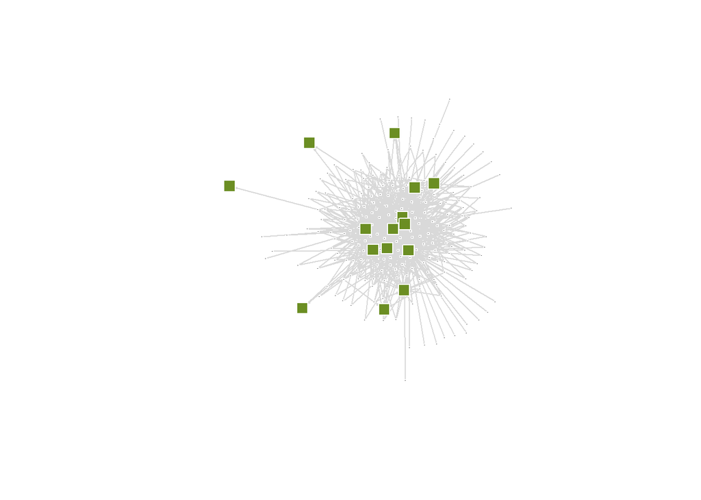

```r
#노드의 색과 크기 지정해주기
colors <- ifelse(gubun == "m", "dimgray", "Olive Drab")
sizes <- ifelse(gubun == "m", 2, 8)
shapes <- ifelse(gubun == "s", "square", "circle")
plot(g, layout = layout.fruchterman.reingold,
     vertex.size = sizes, vertex.shape = shapes, vertex.color = colors, vertex.label = NA, repulserad=vcount(g)^4,
     edge.arrow.size = 0.1, edge.color="gray85",vertex.frame.color="#ffffff")
```

위 그래프에서 알고싶은 것은 모델들이 어떤 스타일을 많이 타겟으로 잡았는지 확인해볼 수 있습니다. 그래프에서 외곽에 배치된 스타일 노드들은 라벨을 표시하여 확인했을 때, “비즈니스”, “힙합”, “애슬레저”, “여행”, “바캉스”으로 나타납니다. 다음과 같은 스타일은 호불호가 많이 갈라지거나 특정한 환경이나 상황에서 입는 스타일이어서 모델들이 많이 선택하지 않는 것이라고 생각합니다.

### 모델-스타일 그래프(man) 분석

네트워크 분석 지표로 연결수로 중요도를 측정하는 연결 중심성, degree가 높은 노드간에 얼마나 잘 연결이 되는지 상관도, 근접 중심성, 고유벡터 중심성을 사용하여 네트워크를 살펴보았습니다.

```r
#연결 중심성
centr_degree(g)
```

```
## $res
##   [1]   5   5   6   5   6  10   1   2   4   3   3   9  10   2   6   2   4   3
##  [19]   8   5   4   6   5   1   3   6   4   3   6   3   9   3   2   7   1   5
##  [37]   1   4   1   1   8   5   1   4   1   6   8   5   7   6   8   7   7  10
##  [55]   3   9   1  11   7   6   8  11   1   7   5   5   5   4   3   5   9   7
##  [73]   4   5   4   5   9   6   4   5   8   4   6   6   6   5   2   6   6   6
##  [91]   2   7   2   3   2   2   3   2   1   3   1   2   1   1   8   3   2   3
## [109]   5   2  11   3   9   4   3   1   3   2   5   2   5   4   1   1   3   2
## [127]   2   2   4   1   7   6   4   5   2   8   3   5   2   6   9   5   4   6
## [145]   3   4   4   8   1   5   4   2   7   5   4   2   6   2   1   4   8   3
## [163]   5   1   1   4   5   6   2   3   6   1   3   2   1   1   1   5   2   3
## [181]   4   4   4   3   5   3   3   2   5   1   4   2   3   3   2   2   1   3
## [199]   5   6   4   5   2   3   3 260 113  40 110 141  64  29   9  55  27   2
## [217]   4   6   2   1
##
## $centralization
## [1] 0.5783241
##
## $theoretical_max
## [1] 95922
```

```r
#상관도
assortativity.degree(g) # 거의 상관도가 없다 (0에 가까움)
```

```
## [1] -0.190527
```

 -0.19에 가까운 수치이므로 상관성이 거의 없다고 볼 수 있습니다.

```r
#중개 중심성
betweenness(g)
```

```
##   m케이타   m정도현   m남윤수   m안정훈   m고현민   m강준석     m레오   m장태희
##         0         0         0         0         0         0         0         0
##   m황준영   m민동률   m조연수     m허현   m박승지     m테이   m전도영     m광복
##         0         0         0         0         0         0         0         0
##   m문민혁   m엄건식   m이종원   m김준수   m노승화   m김태민   m이현석   m김봉우
##         0         0         0         0         0         0         0         0
##   m이재선   m김태현   m변동원   m윤동주   m이재석   m류상희   m김원기   m장동건
##         0         0         0         0         0         0         0         0
##   m한주호   m박상혁   m최겨울   m이영훈   m이노건   m김성수   m위승준   m문경관
##         0         0         0         0         0         0         0         0
##   m이태일   m공도유   m이시연   m이명로   m이주은   m현우석   m백준영   m김성연
##         0         0         0         0         0         0         0         0
##   m강재원   m김현탁   m이한혁   m김상헌   m지호현   m김태원     m서하   m윤정민
##         0         0         0         0         0         0         0         0
##     m구구   m이상건   m윤현조   m김현호   m강경오   m권예찬   m강동혁   m이재무
##         0         0         0         0         0         0         0         0
##   m이충협     m위헝   m오재현   m윤정재   m고동범   m남상원   m박준성   m김원옥
##         0         0         0         0         0         0         0         0
##   m김영준   m박재영   m백상훈     m댄박   m김탁현   m김종수   m이재민   m이명관
##         0         0         0         0         0         0         0         0
##   m서진수   m박범준   m유성찬   m송현근   m오재영   m김정훈   m김다빈   m송호준
##         0         0         0         0         0         0         0         0
##   m안재형   m김진곤     m신호     m김한   m평동균   m백재민   m이학준   m신동수
##         0         0         0         0         0         0         0         0
##   m김경엽   m유경규   m정민영   m노아주   m박성현   m전유호   m김주완   m김재훈
##         0         0         0         0         0         0         0         0
##   m김승태   m오영수     m제아   m홍현우   m구경모   m박재연   m김승우   m정준희
##         0         0         0         0         0         0         0         0
##   m정석영   m이강민   m김충의   m이건희   m김승후   m조승혁   m강동윤   m이충호
##         0         0         0         0         0         0         0         0
##   m지원혁     m유고   m음환희   m박호영     m김환   m이재영   m이정욱   m이재원
##         0         0         0         0         0         0         0         0
##   m조정흠   m최정갑   m김어진   m김동주   m이근우   m류한빈   m박동선   m백성철
##         0         0         0         0         0         0         0         0
##   m황진호   m정지섭   m정승원   m권태민   m오시원   m이성신   m박종현   m주원대
##         0         0         0         0         0         0         0         0
##   m윤태양   m김종석   m김태연   m최성진   m김민혁   m김형권   m김재원   m오종혁
##         0         0         0         0         0         0         0         0
##   m임기용   m김용휘   m최진원     m료타   m김민규   m송재승   m임동률   m이하림
##         0         0         0         0         0         0         0         0
##   m임재완   m이광연     m류한     m박찬   m조영재   m이기택   m유현종   m김영석
##         0         0         0         0         0         0         0         0
##   m차현승   m신유일   m이태훈   m이재성   m신지용   m김예찬   m이종대   m김수겸
##         0         0         0         0         0         0         0         0
##   m배지훈   m이정현   m정희수   m고명재   m권태은   m황성윤   m김혁우   m김현우
##         0         0         0         0         0         0         0         0
##   m손원익   m신윤제   m신진경   m김대은   m김선민   m홍성훈   m유지호   m에이지
##         0         0         0         0         0         0         0         0
##   m장철준   m장원재   m김성결   m백선우   m황민준   m한웅비   m신용국   m유현우
##         0         0         0         0         0         0         0         0
##   m함재민   m조현민   m최효근   m강창모   m손현우   s캐주얼     s댄디     s유스
##         0         0         0         0         0         0         0         0
##     s포멀   s스트릿   s스포츠     s스쿨   s레트로   s캠퍼스   s데이트     s힙합
##         0         0         0         0         0         0         0         0
## s애슬레저     s여행   s바캉스 s비즈니스
##         0         0         0         0
```

 중간에 연결된 노드들이 없다는 것을 확인할 수 있고 그래프에서도 나타납니다.

```r
#근접 중심성
min(closeness(g,mode = "out"))
```

```
## [1] 2.07555e-05
```

```r
max(closeness(g,mode = "out"))
```

```
## [1] 2.164081e-05
```

 2.07555e-05~ 2.164081e-05 사이의 값으로 나오므로 모두 비슷하게 접근한다고 볼 수 있습니다.

```r
# 고유벡터 중심성(중앙성)
which.max(eigen_centrality(g)$vector)
```

```
## s캐주얼
##     206
```

 노드가 많아 eigenvector centrality가 가장 큰 값을 찾았더니 캐주얼이 나오기 때문에 ’캐주얼’노드가 가장 중앙성이 큰 노드라는 것을 확인할 수 있습니다.

### [styling_woman] 데이터 전처리

남성 모델-스타일 전처리 단계에서 비슷한 스타일을 하나의 스타일로 묶을 수 있도록 여성 스타일을 확인하였습니다.

```r
###woman
##모델과 스타일간의 관계
#데이터 전처리
levels(styling_woman$style_class) #스타일 확인
```

위의 데이터 전처리 작업과 동일하게, 스타일변수와 모델변수를 하나의 데이터프레임으로 만들어주었고, source를 모델로 target을 스타일로 잡았습니다.

```r
style <- as.character(styling_woman[,5])
model <- as.character(styling_woman[,7])
w_style_model <- cbind(style,model)
w_style_model <- as.data.frame(w_style_model, stringsAsFactors = FALSE)

w_style_model <- w_style_model[,c(2,1)] #source : 모델 , target : 스타일

str(w_style_model,5)
```

```
## 'data.frame':    1920 obs. of  2 variables:
##  $ model: chr  "유채림" "문주연" "류서현" "송혜인" ...
##  $ style: chr  "캐주얼" "스트릿" "포멀" "걸리시" ...
```

```r
#중복되는 행 제거
woman<-unique(w_style_model)
nrow(unique(woman)) #중복제거완료
```

```
## [1] 614
```

또한, 모델과 스타일을 구분하여 그래프를 그릴 수 있도록 구분자를 생성해주었습니다.

```r
#구분할 수 있게 표시
library(stringr)
woman$model <- paste0("w",woman$model) #앞에 모델 표시로 w붙이기
woman$style <- paste0("s",woman$style) #앞에 스타일 표시로 s붙이기
head(woman,5)
```

```
##     model   style
## 1 w유채림 s캐주얼
## 2 w문주연 s스트릿
## 3 w류서현   s포멀
## 4 w송혜인 s걸리시
## 5 w류서현 s스트릿
```

```r
#그래프 그리기
library(igraph)

g2 <- graph.data.frame(woman,directed =T) #방향성

#구분 값
gubun2<-V(g2)$name
gubun <- str_sub(gubun2, start=1, end =1) #s와 m으로 구분
```

### 모델-스타일 그래프(woman)

모델과 스타일이 그래프상에서 차이가 날 수 있도록 구분자를 이용하여 색과 크기를 지정하였고 이를 그래프로 나타나보았습니다.

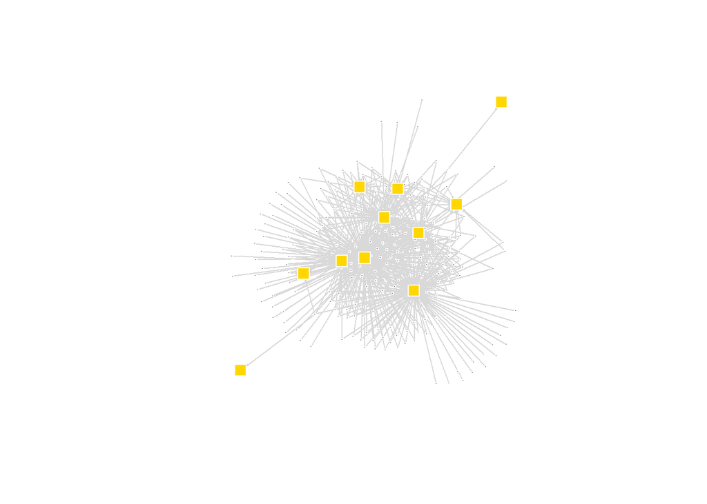

```r
#노드의 색과 크기 지정해주기
colors <- ifelse(gubun == "w", "dimgray", "gold")
sizes <- ifelse(gubun == "w", 2, 8)
shapes <- ifelse(gubun == "s", "square", "circle")
plot(g2, layout = layout.fruchterman.reingold,
     vertex.size = sizes, vertex.shape = shapes, vertex.color = colors, vertex.label = NA, repulserad=vcount(g)^4,
     edge.arrow.size = 0.1, edge.color="gray85",vertex.frame.color="#ffffff")
```

위의 남성 그래프 모양과 비슷하게 나왔으며 그래프에서 외곽에 배치된 스타일 노드들은 “스쿨”, “여행”, “페미닌”으로 나타납니다. 마찬가지로 호불호가 많이 갈리거나 특정한 환경이나 상황에서 입는 스타일이어서 많은 모델들이 선택하지 않는 것이라고 생각합니다.

### 모델-스타일 그래프(woman) 분석

네트워크 분석 지표로 연결수로 중요도를 측정하는 연결 중심성, degree가 높은 노드간에 얼마나 잘 연결이 되는지 상관도, 근접 중심성, 고유벡터 중심성을 사용하여 네트워크를 살펴보았습니다.

```r
#연결 중심성
centr_degree(g2)
```

```
## $res
##   [1]   4   4   4   6   3   2   1   1   4   2   3   4   4   2   5   3   3   3
##  [19]   3   2   4   1   5   2   3   4   3   3   4   3   2   2   2   5   3   5
##  [37]   1   6   2   1   1   1   3   4   5   3   4   3   3   5   4   5   1   4
##  [55]   5   3   5   6   4   4   2   4   6   3   3   3   3   5   4   5   3   4
##  [73]   3   3   4   4   2   2   4   6   3   1   1   2   3   3   1   3   2   3
##  [91]   2   1   1   1   3   2   2   3   2   1   2   2   1   1   1   3   4   3
## [109]   2   3   6   1   3   2   2   2   3   2   3   2   2   5   2   6   2   1
## [127]   1   1   1   5   3   3   5   3   1   4   1   2   3   6   1   1   1   1
## [145]   1   3   4   3   2   2   2   3   1   2   3   3   2   4   1   2   2   1
## [163]   1   1   4   2   2   2   1   3   2   1   2   5   2   1   2   3   1   1
## [181]   4   5   4   2   4   2   1   1   2   1   3   4   6   2   5   2   3   3
## [199]   2   3   7   3   4   4   2   2   1   1   3   2   3   1   1   1   3   4
## [217]   1   1   4   3   3   2   3 189 137  77  79  72   5  13   1  16  24   1
##
## $centralization
## [1] 0.3960102
##
## $theoretical_max
## [1] 108578
```

 가장 많이 연결된 노드는 189개의 연결을 가지고 중심성은 0.39이므로 거의 평등하다고 볼 수 있습니다.  모델, 스타일의 각 노드들이 모두 들어가 계산되어 있으므로, 각 모델-모델 연결은 비슷하나 모델-스타일 연결은 차이가 확실하게 보입니다.

```r
#상관도
assortativity.degree(g2) # 거의 상관도가 없다 (0에 가까움)
```

```
## [1] -0.3136636
```

 -0.31으로 0에 가까운 수치이므로 상관성이 별로 없다고 볼 수 있습니다.

```r
#중개 중심성
betweenness(g2)
```

```
##     w유채림     w문주연     w류서현     w송혜인     w조은서     w김의진
##           0           0           0           0           0           0
##     w박민영     w오송화     w박수완     w송설희     w우정아       w마리
##           0           0           0           0           0           0
##     w이하연     w정청솔     w최예나     w김도영     w제이미     w강초원
##           0           0           0           0           0           0
##     w김승희     w이수진     w서제란       w미오     w나이루     w이혜연
##           0           0           0           0           0           0
##     w박아련     w이진하     w윤재선       w미미     w김수진     w이현영
##           0           0           0           0           0           0
##     w박서희     w박규원     w오은비     w허다솜     w이진아     w지소연
##           0           0           0           0           0           0
##     w이주은     w정민영     w염수진     w이하나     w연지예     w양경은
##           0           0           0           0           0           0
##     w윤선영     w김주연     w주혜원     w변하영       w소이     w한현주
##           0           0           0           0           0           0
##     w임지혜     w최소윤     w황정원     w강미지     w김준수     w이보영
##           0           0           0           0           0           0
##     w김은서     w손세정     w김지호     w강서진     w이유진     w현예진
##           0           0           0           0           0           0
##     w어유진     w박경민       w한봄     w장해민     w박새미     w김지아
##           0           0           0           0           0           0
##     w솜해인     w박은주     w이수빈     w김효빈     w신혜란     w최민화
##           0           0           0           0           0           0
##     w박영빈     w김하늘     w신화진     w문다현     w백은경     w김주경
##           0           0           0           0           0           0
##     w송해인     w사유빈       w호징     w민지원     w박서진     w아리엘
##           0           0           0           0           0           0
##     w김연수     w정회린     w한양희     w이채령     w송채운     w노시원
##           0           0           0           0           0           0
##     w김유라     w고가영     w윤지원     w신현서     w선혜영     w구효민
##           0           0           0           0           0           0
##     w홍유리     w최세임       w재림       w윤진     w서지수       w은비
##           0           0           0           0           0           0
##     w김수현 w페어리티나     w전주희     w박세원     w김보영     w김로사
##           0           0           0           0           0           0
##     w라은하     w양지윤     w김정은     w김미미     w손효은       w엄지
##           0           0           0           0           0           0
##     w이예지     w강민지     w박시호     w심유진     w곽린애     w이담희
##           0           0           0           0           0           0
```

[output cut: 23 more lines]

```
##           0           0           0           0           0           0
##     w윤빛나     w김규연     w차유진     w김샤나     w김혜연     w이윤진
##           0           0           0           0           0           0
##       w리나     w김여은     w김예영     w채유진     w김현제     w이현정
##           0           0           0           0           0           0
##     w이아림     w한지원     w채예리     w김선희     w최지수       w권샘
##           0           0           0           0           0           0
##     w노주영     w전민하     w홍지수     w김문주     w성예진       w이달
##           0           0           0           0           0           0
##     w박혜린     w주서연     w신은지     w윤제이     w이진실     w조예림
##           0           0           0           0           0           0
##     w우시은     s캐주얼     s스트릿       s포멀     s걸리시     s스포츠
##           0           0           0           0           0           0
##       s여행   s비즈니스       s스쿨       s시크     s로맨틱     s페미닌
##           0           0           0           0           0           0
```

 중간에 연결된 노드들이 없다는 것을 확인할 수 있고 그래프에서도 나타납니다.

```r
#근접 중심성
min(closeness(g2,mode = "out"))
```

```
## [1] 1.834122e-05
```

```r
max(closeness(g2,mode = "out"))
```

```
## [1] 1.890681e-05
```

 1.834122e-05~ 1.890681e-05 사이의 값으로 나오므로 모두 비슷하게 접근한다고 볼 수 있습니다.

```r
# 고유벡터 중심성(중앙성)
which.max(eigen_centrality(g2)$vector)
```

```
## s캐주얼
##     224
```

 노드가 많아 eigenvector centrality가 가장 큰 값을 찾았더니 캐주얼이 나오기 때문에 ’캐주얼’노드가 가장 중앙성이 큰 노드라는 것을 확인할 수 있습니다.

## 분석 정리

**<모델과 스타일간의 관계>**

- 각 모델들이 어떤 스타일을 타겟으로 잡았는지 그래프를 그려봤을 때, 외곽에 배치된 스타일 노드들은 가운데 위치 된 노드보다 상대적으로 호불호가 갈라지거나 특정한 환경이나 상황에서 입는 스타일이라는 것을 알 수 있었습니다.
- 모델-모델 연결은 비슷하나 모델-스타일 연결은 차이가 확실하게 보이며 그 중 ‘캐주얼’ 스타일이 모델들이 가장 많이 선택하고 연결 되어있는 것을 알 수 있으며 이는 성별을 가리지 않고 알 수 있었습니다.

## ————————————————————————

# 2. 스타일과 스타일간의 관계

위의 분석에서 모델-스타일 연결은 차이가 확실한 것을 알 수 있었습니다. 이에 모델 수에 따른 스타일-스타일 관계도 알고자 그래프와 분석지표를 통해 확인해보았습니다.

### [styling_man] 데이터 전처리

비슷한 스타일들은 하나의 스타일로 묶어주고 행의 값이 같은 데이터들의 중복값을 제거해주었습니다.

```r
#데이터 전처리
style <- as.character(styling_man[,5])
model <- as.character(styling_man[,7])

style <- gsub(" ", "", style)
style <- gsub("스포츠캐주얼","스포츠",style)
style <- gsub("이지캐주얼","캐주얼",style)
style <- gsub("세미포멀","포멀",style)

ms_c <- cbind(model,style)
ms_c <- unique(ms_c) #중복값 제거
ms <- as.data.frame(ms_c, stringsAsFactors = FALSE)
ms <- ms[,c(2,1)] #전처리 완료된 최종 데이터

head(ms,5)
```

```
##    style  model
## 1 캐주얼 케이타
## 2 캐주얼 정도현
## 3   댄디 남윤수
## 4   댄디 안정훈
## 5   댄디 고현민
```

### 인접행렬 구성

인접행렬을 만들어 모델을 제거한 스타일 간의 행렬을 구성하였으며, 자기자신으로 돌아오는 루프를 없애기 위하여 대각선에 0을 넣었습니다.

```r
#스타일-스타일 인접행렬
sg <- graph_from_data_frame(ms)

V(sg)$type <- bipartite_mapping(sg)$type
sm <-as_incidence_matrix(sg) %*% t(as_incidence_matrix(sg))
diag(sm) <- 0
sm
```

```
##          캐주얼 댄디 유스 포멀 스트릿 스포츠 스쿨 레트로 캠퍼스 데이트 힙합
## 캐주얼        0  164   61  164    194    107   46     13     73     38    3
## 댄디        164    0   29   78     85     48   24      7     36     16    2
## 유스         61   29    0   29     31     26   11      1     13      7    1
## 포멀        164   78   29    0     83     58   27     10     39     19    1
## 스트릿      194   85   31   83      0     55   24      8     37     23    2
## 스포츠      107   48   26   58     55      0   19      5     24     13    1
## 스쿨         46   24   11   27     24     19    0      5      7      3    0
## 레트로       13    7    1   10      8      5    5      0      2      2    1
## 캠퍼스       73   36   13   39     37     24    7      2      0     14    1
## 데이트       38   16    7   19     23     13    3      2     14      0    0
## 힙합          3    2    1    1      2      1    0      1      1      0    0
## 애슬레저      7    3    0    3      4      2    2      1      1      0    0
## 여행          9    5    0    6      5      3    1      0      3      4    0
## 바캉스        4    2    0    1      2      2    0      0      2      0    0
## 비즈니스      2    1    0    0      0      0    0      0      1      0    0
##          애슬레저 여행 바캉스 비즈니스
## 캐주얼          7    9      4        2
## 댄디            3    5      2        1
## 유스            0    0      0        0
## 포멀            3    6      1        0
## 스트릿          4    5      2        0
## 스포츠          2    3      2        0
## 스쿨            2    1      0        0
## 레트로          1    0      0        0
## 캠퍼스          1    3      2        1
## 데이트          0    4      0        0
## 힙합            0    0      0        0
## 애슬레저        0    0      0        0
## 여행            0    0      0        0
## 바캉스          0    0      0        0
## 비즈니스        0    0      0        0
```

### 스타일-스타일 그래프(man)

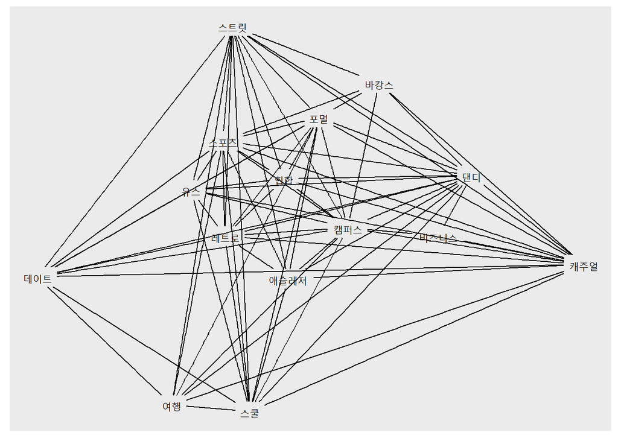

```r
#그래프 그리기
library(tidygraph)
library(ggraph)
sm %>% as_tbl_graph() %>%
  ggraph(layout = "kk") +
  geom_edge_link(aes(start_cap = label_rect(node1.name), end_cap = label_rect(node2.name))) +
  geom_node_text(aes(label = name))
```

그래프 중앙에서 브로커 역할을 하는 스타일들을 확인할 수 있었으며, 그래프 외곽에 있는 스타일들은 분석 지표에서도 확인할 수 있듯이 그래프 중앙에 있는 스타일보다 연결성, 중개성이 높은 스타일이란 것을 확인할 수 있습니다.

### 스타일-스타일 그래프(man) 분석

```r
##분석 기법
#중앙성
sm %>% as_tbl_graph() %>%
  mutate(pr = centrality_pagerank()) %>%
  arrange(desc(pr)) %>%
  as_tibble
```

```
## # A tibble: 15 x 2
##    name         pr
##    <chr>     <dbl>
##  1 캐주얼   0.0883
##  2 댄디     0.0883
##  3 캠퍼스   0.0883
##  4 스포츠   0.0810
##  5 포멀     0.0810
##  6 스트릿   0.0810
##  7 스쿨     0.0693
##  8 레트로   0.0693
##  9 데이트   0.0637
## 10 유스     0.0637
## 11 여행     0.0527
## 12 힙합     0.0527
## 13 애슬레저 0.0527
## 14 바캉스   0.0420
## 15 비즈니스 0.0261
```

 캐주얼,댄디,캠퍼스가 제일 중심성이 높게 나왔습니다.

```r
#연결 중심성
sm %>% as_tbl_graph() %>%
  mutate(degree = centrality_degree())%>%
  as_tibble
```

```
## # A tibble: 15 x 2
##    name     degree
##    <chr>     <dbl>
##  1 캐주얼       14
##  2 댄디         14
##  3 유스         10
##  4 포멀         13
##  5 스트릿       13
##  6 스포츠       13
##  7 스쿨         11
##  8 레트로       11
##  9 캠퍼스       14
## 10 데이트       10
## 11 힙합          8
## 12 애슬레저      8
## 13 여행          8
## 14 바캉스        6
## 15 비즈니스      3
```

 각 노드의 연결선 수를 확인할 수 있고 캐주얼과 댄디 순으로 가장 많은 것을 확인할 수 있습니다.

```r
#중개중심성
sm %>% as_tbl_graph() %>%
  mutate(mu = centrality_betweenness()) %>%
  as_tibble
```

```
## # A tibble: 15 x 2
##    name        mu
##    <chr>    <dbl>
##  1 캐주얼   12.1
##  2 댄디     12.1
##  3 유스      0.5
##  4 포멀      4.74
##  5 스트릿    4.74
##  6 스포츠    4.74
##  7 스쿨      1.29
##  8 레트로    1.29
##  9 캠퍼스   12.1
## 10 데이트    0.5
## 11 힙합      0
## 12 애슬레저  0
## 13 여행      0
## 14 바캉스    0
## 15 비즈니스  0
```

 중간에 연결된 노드가 제일 많은 것은 캐주얼과 댄디인 것을 확인할 수 있습니다.

```r
#근접성
sm %>% as_tbl_graph() %>%
  mutate(cl = centrality_closeness()) %>%
  as_tibble
```

```
## # A tibble: 15 x 2
##    name         cl
##    <chr>     <dbl>
##  1 캐주얼   0.0714
##  2 댄디     0.0714
##  3 유스     0.0556
##  4 포멀     0.0667
##  5 스트릿   0.0667
##  6 스포츠   0.0667
##  7 스쿨     0.0588
##  8 레트로   0.0588
##  9 캠퍼스   0.0714
## 10 데이트   0.0556
## 11 힙합     0.0500
## 12 애슬레저 0.0500
## 13 여행     0.0500
## 14 바캉스   0.0455
## 15 비즈니스 0.04
```

 가장 빠르게 접근 할 수 있는 노드는 캐주얼과 댄디인 것을 학인할 수 있습니다.

즉, 연결 중심성, 중앙성, 중개 중심성, 근접성 모두 캐주얼, 댄디가 가장 중심성이 높은 것을 확인할 수 있어 중요한 노드라는 것을 확인할 수 있습니다.

### [styling_woman] 데이터 전처리

행의 값이 같은 중복 데이터를 제거하고 style과 model을 하나의 데이터 프레임으로 데이터를 전처리 해주었습니다.

```r
#데이터 전처리
style <- as.character(styling_woman[,5])
model <- as.character(styling_woman[,7])

ms_d <- cbind(model,style)
ms_d <- unique(ms_d) #중복값 제거
ws <- as.data.frame(ms_d, stringsAsFactors = FALSE)
ws <- ws[,c(2,1)] #전처리 완료된 최종 데이터

head(ws)
```

```
##    style  model
## 1 캐주얼 유채림
## 2 스트릿 문주연
## 3   포멀 류서현
## 4 걸리시 송혜인
## 5 스트릿 류서현
## 6 스트릿 조은서
```

### 인접행렬 구성

인접행렬을 만들어 모델을 제거한 스타일 간의 행렬을 구성하였으며, 자기자신으로 돌아오는 루프를 없애기 위하여 대각선에 0을 넣었습니다.

```r
#스타일-스타일 인접행렬
sg_w <- graph_from_data_frame(ws)

V(sg_w)$type <- bipartite_mapping(sg_w)$type
sw <-as_incidence_matrix(sg_w) %*% t(as_incidence_matrix(sg_w))
diag(sw) <- 0
sw
```

```
##          캐주얼 스트릿 포멀 걸리시 스포츠 여행 비즈니스 스쿨 시크 로맨틱 페미닌
## 캐주얼        0    114   70     72     67    5       11    1   14     21      1
## 스트릿      114      0   44     58     51    4        7    1    4     11      0
## 포멀         70     44    0     37     34    1        8    0    8     15      0
## 걸리시       72     58   37      0     29    2        5    0    8     15      1
## 스포츠       67     51   34     29      0    5        2    1    7     10      0
## 여행          5      4    1      2      5    0        0    1    1      0      0
## 비즈니스     11      7    8      5      2    0        0    0    2      3      0
## 스쿨          1      1    0      0      1    1        0    0    0      0      0
## 시크         14      4    8      8      7    1        2    0    0      7      0
## 로맨틱       21     11   15     15     10    0        3    0    7      0      0
## 페미닌        1      0    0      1      0    0        0    0    0      0      0
```

### 스타일-스타일 그래프(woman)

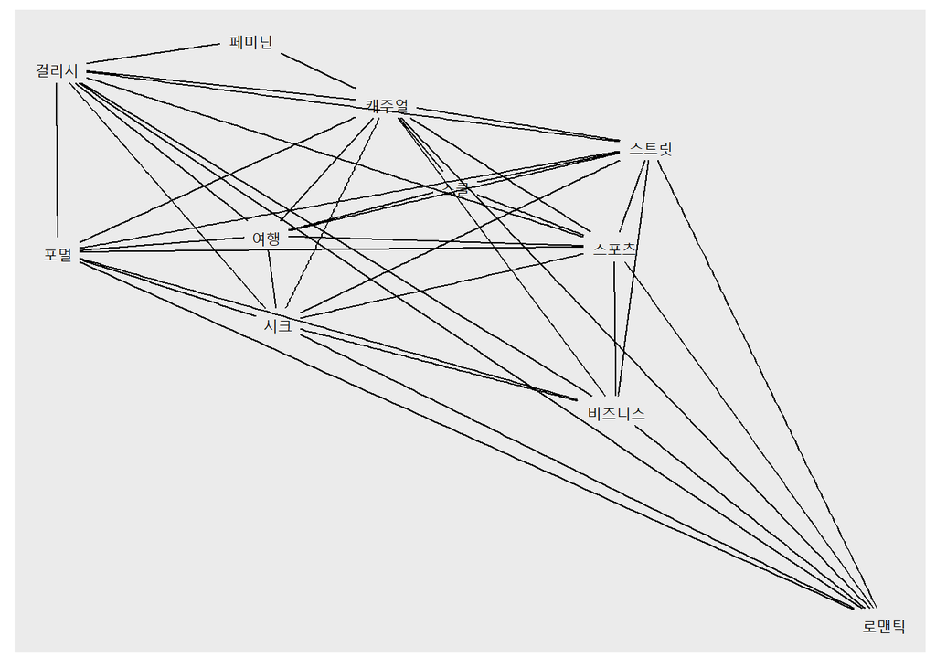

```r
#그래프 그리기
library(tidygraph)
library(ggraph)
sw %>% as_tbl_graph() %>%
  ggraph(layout = "kk") +
  geom_edge_link(aes(start_cap = label_rect(node1.name), end_cap = label_rect(node2.name))) +
  geom_node_text(aes(label = name))
```

### 스타일-스타일 그래프(woman) 분석

```r
##분석 기법
#중앙성
sw %>% as_tbl_graph() %>%
  mutate(pr = centrality_pagerank()) %>%
  arrange(desc(pr)) %>%
  as_tibble
```

```
## # A tibble: 11 x 2
##    name         pr
##    <chr>     <dbl>
##  1 캐주얼   0.124
##  2 걸리시   0.112
##  3 스포츠   0.109
##  4 스트릿   0.109
##  5 포멀     0.0974
##  6 시크     0.0974
##  7 여행     0.0878
##  8 비즈니스 0.0866
##  9 로맨틱   0.0866
## 10 스쿨     0.0554
## 11 페미닌   0.0347
```

 캐주얼이 제일 중심성이 높게 나오고 걸리시, 스포츠 순으로 나타났습니다.

```r
#연결 중심성
sw %>% as_tbl_graph() %>%
  mutate(degree = centrality_degree())%>%
  as_tibble
```

```
## # A tibble: 11 x 2
##    name     degree
##    <chr>     <dbl>
##  1 캐주얼       10
##  2 스트릿        9
##  3 포멀          8
##  4 걸리시        9
##  5 스포츠        9
##  6 여행          7
##  7 비즈니스      7
##  8 스쿨          4
##  9 시크          8
## 10 로맨틱        7
## 11 페미닌        2
```

 각 노드의 연결선 수를 확인할 수 있고 그 중, 캐주얼과 스트릿, 걸리시 순으로 가장 많은 것으로 나타났습니다.

```r
#중개중심성
sw %>% as_tbl_graph() %>%
  mutate(mu = centrality_betweenness()) %>%
  as_tibble
```

```
## # A tibble: 11 x 2
##    name         mu
##    <chr>     <dbl>
##  1 캐주얼   12.5
##  2 스트릿    3.5
##  3 포멀      0.667
##  4 걸리시    7.67
##  5 스포츠    3.5
##  6 여행      1.5
##  7 비즈니스  0
##  8 스쿨      0
##  9 시크      0.667
## 10 로맨틱    0
## 11 페미닌    0
```

 중간에 연결된 노드가 제일 많은 것은 캐주얼, 걸리시, 스트릿,스포츠 순으로 나타나는 것을 확인할 수 있습니다.

```r
#근접성
sw %>% as_tbl_graph() %>%
  mutate(cl = centrality_closeness()) %>%
  as_tibble
```

```
## # A tibble: 11 x 2
##    name         cl
##    <chr>     <dbl>
##  1 캐주얼   0.1
##  2 스트릿   0.0909
##  3 포멀     0.0833
##  4 걸리시   0.0909
##  5 스포츠   0.0909
##  6 여행     0.0769
##  7 비즈니스 0.0769
##  8 스쿨     0.0625
##  9 시크     0.0833
## 10 로맨틱   0.0769
## 11 페미닌   0.0556
```

 가장 빠르게 접근 할 수 있는 노드는 캐주얼, 스트릿, 걸리시, 스포츠 순으로 나타나는 것을 확인할 수 있습니다.

즉, 연결 중심성, 중앙성, 중개 중심성, 근접성 모두 캐주얼,걸리시,스포츠 순으로 중심성이 높은 것을 확인할 수 있어 중요한 노드라는 것을 확인할 수 있습니다.

## 분석 정리

**<스타일과 스타일간의 관계>**

- 분석지표들은 남, 여 모두 캐주얼이 연결성이 제일 크고 연결선이 제일 많은 것을 확인할 수 있었습니다. 이는 캐주얼은 모든 스타일 노드와 연결되어 있는 것인데 그래프를 보면 확인할 수 있습니다. 캐주얼 노드는 한번에 다른 노드(A)와 연결되거나 브로커(B)노드에 연결되어 A노드에 연결 되는 두가지 EDGE를 확인할 수 있기 때문입니다.
- ’캐주얼’스타일이 압도적으로 큰 영향을 끼친다는 것을 확인하였고 모델-스타일, 스타일-스타일 관계 분석에서 가장 일상생활에서 많이 입는 스타일을 모델들이 타겟으로 잡는다는 것으로 연결지을 수 있습니다.

# 윤길이 파트

**<계절과 스타일간의 관계>**

```r
#패키지 설치
library(igraph)
library(dplyr)
library(tidygraph)
library(ggraph)
library(stringr)
```

```r
#파일 불러오기
setwd('D:/musinsa_store')
st_m <- read.csv("musinsa_styling_data_man.csv", encoding = 'UTF-8')
```

```r
#날짜 뽑아오기
st_m$date <- as.Date(st_m$date)

#사계절로 데이터 나누기
st_m$season <- ifelse(str_sub(st_m$date,6,7)=='09' | str_sub(st_m$date,6,7)=='10'|str_sub(st_m$date,6,7)=='11', '가을',ifelse(str_sub(st_m$date,6,7)=='06' | str_sub(st_m$date,6,7)=='07'|str_sub(st_m$date,6,7)=='08','여름', ifelse(str_sub(st_m$date,6,7)=='03' | str_sub(st_m$date,6,7)=='04'|str_sub(st_m$date,6,7)=='05','봄','겨울')))
```

```r
#계절과 스타일열 합치기
a<-cbind(as.character(st_m$style_class),st_m$season)

#데이터 프레임으로 바꾸기
b<-as.data.frame(a)

#색깔 다르게 해주기
library(unikn)
```

[figure not shown]

```r
hh <- b%>%
  group_by(V2,V1) %>%
  summarise(n = n())
hh<- as.data.frame(hh)
gg<- str_c(hh[,1],' ',hh[,2])
gg <- cbind(gg,hh$n)
gg <- data.frame(gg)
gg$V2<- as.numeric(gg$V2)
#그래프 그리기

G<-graph.data.frame(hh[1:2],directed=F)
par(mar=c(0,0,0,0))

plot(G, layout = layout.fruchterman.reingold,
     vertex.size = sizes, vertex.shape = shapes, vertex.color = colors, vertex.label = NA, repulserad=vcount(g)^4,
     edge.arrow.size = 0.1, edge.color="gray85",vertex.frame.color="#ffffff")
```